# Multivariate Analysis Lecture 02: Matrix Operations

# Spectral Decomposition

## Generate Data from MVN

- Generate 1000 data points from a multivariate normal with mean $\mathbf 0$ and covariance matrix
  $$\Sigma=\begin{pmatrix}0.8125000 & 0.3247595\\
  0.3247595 & 0.4375000\end{pmatrix}$$
- How did I obtain this covariance matrix?

```r
theta=-pi/6
R=matrix(c(cos(theta), -sin(theta), sin(theta), cos(theta)), 2, 2)
Lambda=diag(c(1,0.25))
Sigma=R%*%Lambda%*%t(R)
X=mvrnorm(1000, mu=rep(0,2), Sigma=Sigma)
```

## MVN data: Visualization

- Scatter plot of the data $X$

```r
plot(X, xlim=c(-3,3), ylim=c(-3,3), xlab="", ylab="", main="original")
abline(a=0, b=1/2, col="red")
```

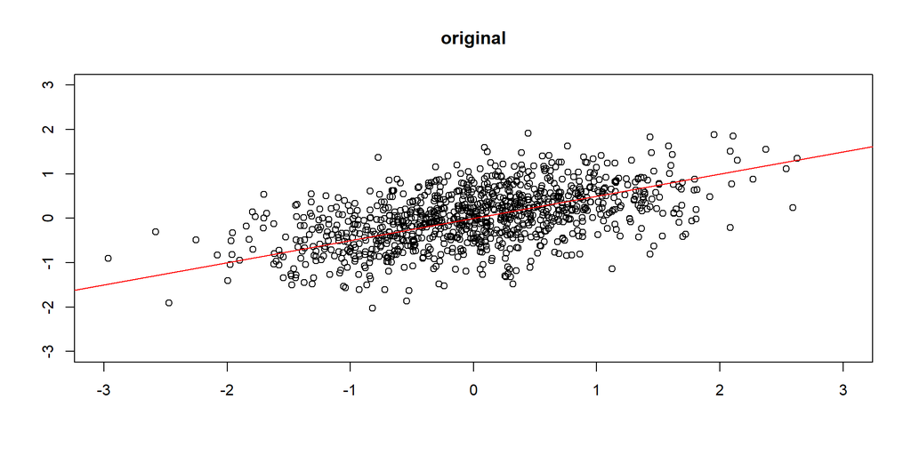

## Spectral Decomposition of Sample Covariance Matrix

- Conduct spectral decomposition of $cov(X)$.

```r
R.obs=eigen(cov(X))$vectors
print(R.obs)
```

```
           [,1]       [,2]
[1,] -0.8554561  0.5178754
[2,] -0.5178754 -0.8554561
```

```r
Lambda.obs=diag(eigen(cov(X))$values)
print(Lambda.obs)
```

```
          [,1]      [,2]
[1,] 0.8683588 0.0000000
[2,] 0.0000000 0.2445993
```

### Spectral Decomposition

- Verify the spectral decomposition of $cov(X)$.

```r
print(cov(X))
```

```
          [,1]      [,2]
[1,] 0.7010697 0.2763377
[2,] 0.2763377 0.4118884
```

```r
print(R.obs%*% Lambda.obs %*% t(R.obs))
```

```
          [,1]      [,2]
[1,] 0.7010697 0.2763377
[2,] 0.2763377 0.4118884
```

### Spectral Decomposition

- standardizing X is equivalent to two steps:
- 1. rotate the n-by-2 data matrix X by multiplying R.
- 2. scale Y by multipling Lambda^{-1/2} to obtain Z

```r
Y=X%*%R.obs
Z=Y%*%diag(1/sqrt(diag(Lambda.obs)))
#note: for each 2-by-1 vector xi, the rotated vector yi is given by
#yi=R.obs^T xi
```

### Spectral Decomposition

```r
par(mfrow=c(2,2))
plot(X, xlim=c(-3,3), ylim=c(-3,3), xlab="", ylab="", main="original")
abline(a=0, b=1/2, col="red")
plot(Y, xlim=c(-3,3), ylim=c(-3,3), xlab="", ylab="", main="rotated")
plot(Z, xlim=c(-3,3), ylim=c(-3,3), xlab="", ylab="", main="rorated+rescaled")
```

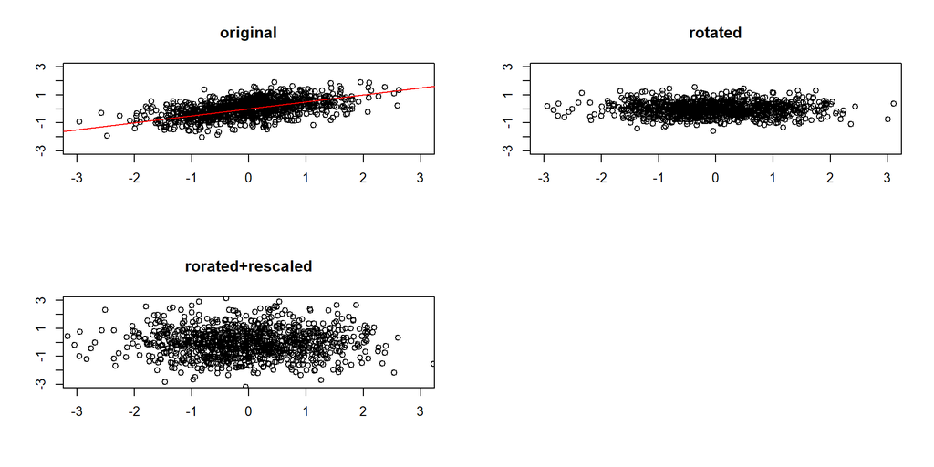

### Spectral Decomposition

- Let’s reverse the process
- 1. rescale $Z$ by multiplying Lambda.obs^{1/2} to obtain $Y$
- 2. rotate $Y$ by multiplying $R^T$ to obtain $X$

```r
Y=Z%*%sqrt(Lambda.obs)
X.recovered=Y%*%t(R.obs)
```

### Spectral Decomposition

```r
par(mfrow=c(2,2))
plot(X, xlim=c(-3,3), ylim=c(-3,3), xlab="", ylab="", main="original")
abline(a=0, b=1/2, col="red")
plot(Y, xlim=c(-3,3), ylim=c(-3,3), xlab="", ylab="", main="rotated")
plot(Z, xlim=c(-3,3), ylim=c(-3,3), xlab="", ylab="", main="rorated+rescaled")
plot(X.recovered, xlim=c(-3,3), ylim=c(-3,3), xlab="", ylab="", main="recovered")
```

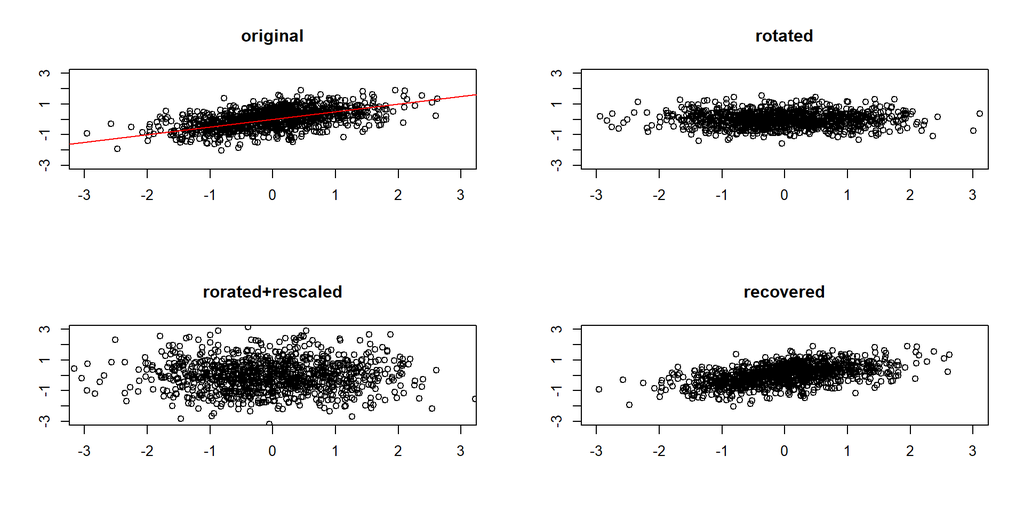

# SVD

## Singular Value Decomposition (SVD)

### Introduction to SVD

- SVD was developed by a number of researchers independently over time. Key contributors
  - Eugenio Beltrami (1873): an Italian mathematician, first introduced the concept of singular value decomposition in his work on mathematical physics, although the modern formulation of SVD was not fully realized at that time.
  - Camille Jordan (1874), a French mathematician, independently discovered it.
  - … Many other contributors …
  - Gene H. Golub and Charles F. Van Loan (1965): American mathematicians, are credited with the development of the modern and widely used algorithm for computing the singular value decomposition, known as the Golub-Reinsch algorithm.

### What is SVD?

- SVD is a useful factorization of a rectangular matrix A into three matrices
- If $A$ is an $n\times p$ matrix of rank $r$,then A can be written as
  $$A_{n\times p} = U_{n\times r} D_{r\times r} V_{r\times p}^T$$
  where
  - $U_{n\times r}$ and $V_{r\times p}$ are column orthogonal matrices, i.e.,
    $$U^TU=V^TV=\mathbf I_{r}$$
  - $U$ is the left singular vectors matrix, contains the eigenvectors of $AA^T$ (n x n matrix)
  - V^T is right singular vectors matrix, contains the eigenvectors of $A^TA$ (p x p matrix)
  - $D$ is diagonal matrix of singular values, contains the square root of the eigenvalues of $AA^T$ and $A^TA$

### Intuition behind SVD

- SVD helps us understand the linear transformation of a matrix in terms of its components: rotation, scaling, and reflection.
- $U$ and $V^T$ represent rotations in the input and output spaces respectively, while $D$ represents scaling along the axes.
- SVD allows us to find a lower-dimensional representation of the data by capturing the most important singular values and their corresponding singular vectors.

### Applications of SVD

- SVD can be used for various applications such as image compression, recommendation systems, and data analysis.
  - Image Compression: SVD can be used to reduce the size of an image by compressing it while retaining its important features.
  - Recommendation Systems: SVD can be used to make personalized recommendations in recommendation systems by factorizing user-item interaction matrices.
  - Data Analysis: SVD can be used for dimension reduction, noise reduction, and feature extraction in data analysis tasks such as clustering, classification, and regression.

### SVD for image compression

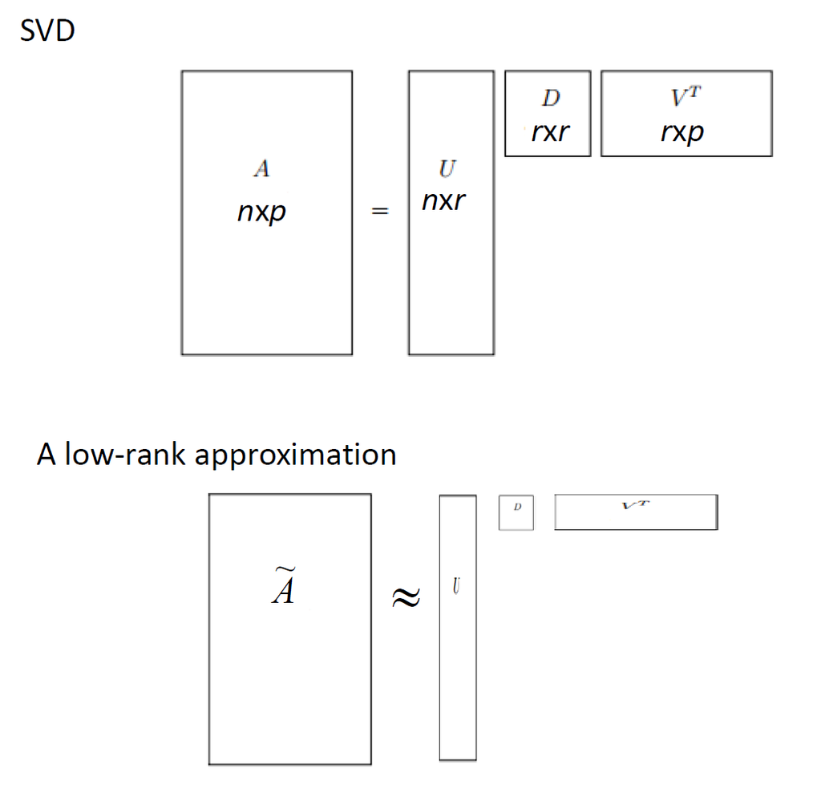

### SVD: Example 1

- The original image

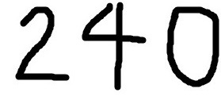

### SVD: Example 1

```r
#install and load "jpeg"
library(jpeg)
mydata=readJPEG("img/svdexample.jpg", native = FALSE)
mydata=mydata[,,1] #279-by-131
obj=svd(mydata)
#obj$u: a 279-by-131 matrix
#obj$d: a vector of 131 nonnegative values
#obj$v: a 131-by-131 matrix
```

### SVD Example 1: R

```r
par(mfrow=c(2,2))
#image(mydata,col=gray(c(0:10)/10))

image(t(mydata)[,nrow(mydata):1],col=gray(c(0:10)/10),
      xlab="", ylab="", main="original")

plot(obj$d, ylab="singular values")

n=1
mydata.approx=obj$u[,1] %*% t(obj$v[,1])*obj$d[1]
image(t(mydata.approx)[, nrow(mydata.approx):1], main="rank 1", col=gray(c(0:10)/10))

n=10
mydata.approx=obj$u[,1:n]%*% diag(obj$d[1:n]) %*% t(obj$v[,1:n])
image(t(mydata.approx)[, nrow(mydata.approx):1], main="rank 10", col=gray(c(0:10)/10))
```

### SVD Example 1: R

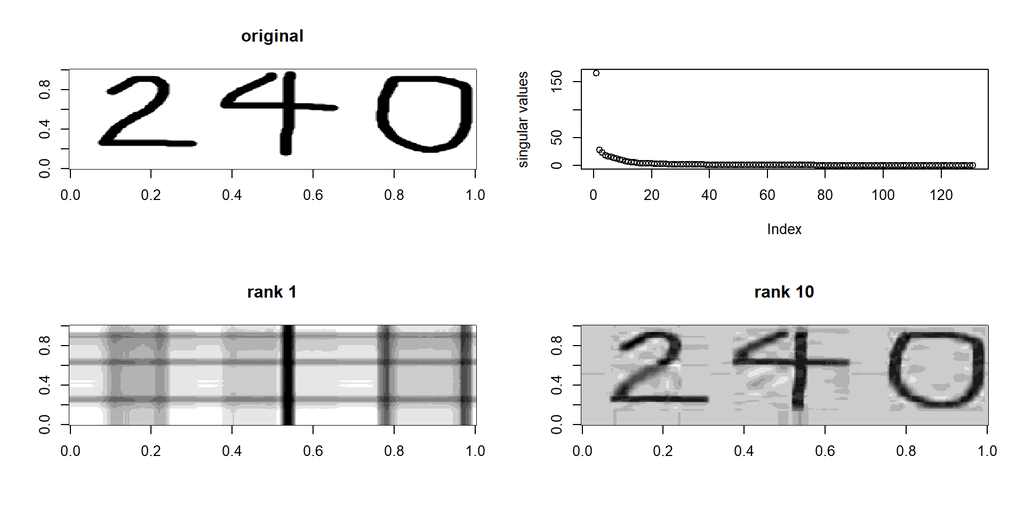

### SVD: Example 2

```r
BikeMan=readJPEG("BikeMan.jpg", native = FALSE)
BikeMan=BikeMan[,,1]

par(mfrow=c(2,2))
image(BikeMan, col=gray(c(0:10)/10))
obj.bm=svd(BikeMan)

n=10
BikeMan.approx=obj.bm$u[,1:n]%*% diag(obj.bm$d[1:n]) %*% t(obj.bm$v[,1:n])
image(BikeMan.approx, main="rank 10", col=gray(c(0:10)/10))

n=20
BikeMan.approx=obj.bm$u[,1:n]%*% diag(obj.bm$d[1:n]) %*% t(obj.bm$v[,1:n])
image(BikeMan.approx, main="rank 20", col=gray(c(0:10)/10))

n=30
BikeMan.approx=obj.bm$u[,1:n]%*% diag(obj.bm$d[1:n]) %*% t(obj.bm$v[,1:n])
image(BikeMan.approx, main="rank 30", col=gray(c(0:10)/10))
```

### SVD: Example 2

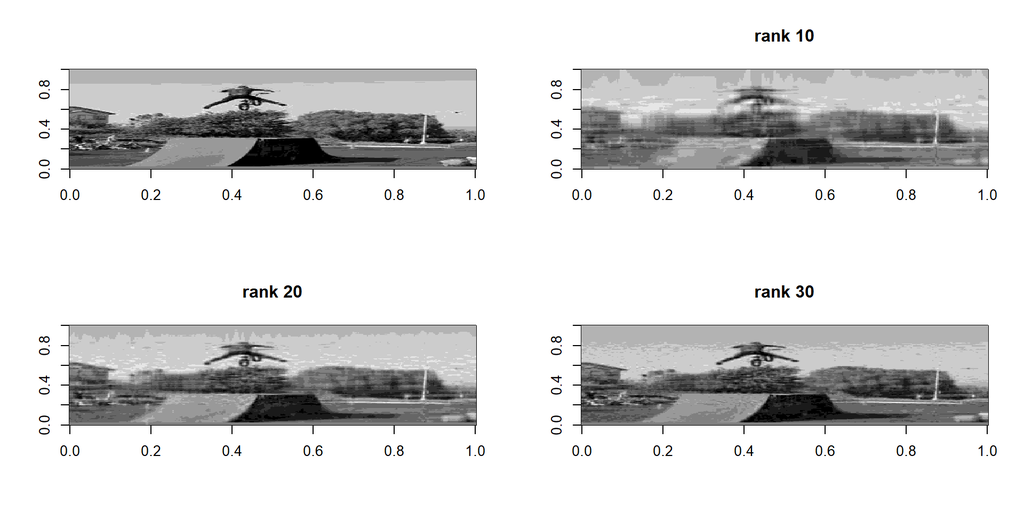

# Kronecker

## Another Matrix Operation: Kronecker Product

### Definition

- The Kronecker product, denoted by $\bigotimes$ is a mathematical operation that combines two matrices to create a larger matrix.
- According to wikipedia, “The Kronecker product is named after the German mathematician Leopold Kronecker (1823–1891), even though there is little evidence that he was the first to define and use it.”
- Why is it useful? It provide compact Representation. Kronecker product allows for compact representation of large matrices by expressing them as a combination of smaller matrices.

### Definition

Let
$$A_{m\times n}=\begin{pmatrix}
a_{11} & \cdots & a_{1n}\\
\cdots & \cdots & \cdots\\
a_{m1} & \cdots & a_{mn}\\
\end{pmatrix},
B_{p\times q}=\begin{pmatrix}
b_{11} & \cdots & b_{1q}\\
\cdots & \cdots & \cdots\\
b_{p1} & \cdots & b_{pq}\\
\end{pmatrix}$$
Then,
$$A \bigotimes B =
\begin{pmatrix}
a_{11} * B & a_{12} * B & ... & a_{1n} * B \\
\cdots & \cdots & \cdots & \cdots\\
a_{m1} * B & a_{m2} * B & ... & a_{mn} * B
\end{pmatrix}$$

### Definition

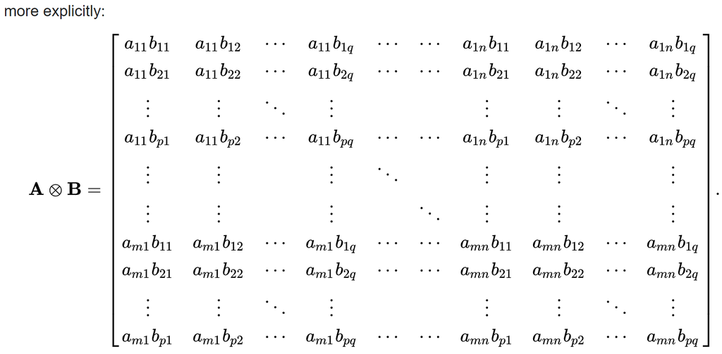

## Futher reading

- Chronecker product: Gerald S. Rogers. (1984) Kronecker Products in ANOVA-A First Step. The American Statistician, 38: 197-202.
- SVD: Biclustering via Sparse Singular Value Decomposition” https://www.unc.edu/~haipeng/publication/ssvd.pdf

# Homework 1

## Homework 1

### Problem 1

- Suppose $X_1, X_2, Y_1, Y_2$ are mutually independent.
  - $X_1$ and $X_2$ are iid from $N(\mu=0, \sigma_x^2=2^2)$
  - $Y_1$ and $Y_2$ are iid from $N(\mu=0, \sigma_y^2=1^2)$ Consider the two pairs $(X_1, X_2)$ and $(Y_1, Y_2)$. Which pair tends to have a larger difference? To answer the question, please calculate and estimate the following two probabilities:
    $$P(|X_1-X_2|>4), P(|Y_1-Y_2|>4)$$
- The hints for calculating/estimating $P(|X_1-X_2|>4)$ can be found in the two slides. Using similar strategies, you can calculate/estimate $P(|Y_1-Y_2|>4)$

### Calculate $P(|X_1-X_2|>4)$

- Hints for calculating $P(|X_1-X_2|>4)$.
  - First find the distribution of $X_1-X_2$. Then standard it to have mean 0 and SD 1.
  - Second, express the probability to $P(|Z|>z)$, where $Z\sim N(0,1)$.
  - Next, expression the probability in terms of $\Phi(\cdot)$, the CDF of the standard normal distribution.
  - Last, use the “pnorm” function in R to find the numerical value.

### Estimate $P(|X_1-X_2|>4)$

- The probability can be estimated by doing simulations/sampling.
- If you sample many (say 10,000) pairs of $X_1$ and $X_2$, count how many pairs satisfying $|X_1-X_2|>4$. The probability can be used to estimate $P(|X_1-X_2|>4)$

### Problem 2

- Find a matrix $A$ such that $AY$ gives the difference of mean vectors between iris setosa and iris versicolor
- Find a matrix $B$ such that $YB$ is column-standardized, i.e., the standard deviation of each column/feature is 1.
- Check the following
  - Let $C=\mathbf I_{150} - \frac{1}{150}J$, where $J_{150\times 150}$ is an all-ones matrices . Use R to verify that $CY$ centers each column/feature. The R code for $C$ is ”

  ```
  C=diag(1,150) - \frac{1}{150}matrix(1, 150, 150)
  ```

  - Let $S$ be the sample covariance matrix. Use R to verify that each column of $CYS^{-1/2}$ has been centered and standardized (in fact, the columns have also been de-correlated). Hints:

  ```
  S=cov(Y)
  ```

  To compute $S^{-1/2}$, you may need an R package, such as “qtl2pleio”.

### Problem 3

- Choose a picture you like and conduct approximations using singular value decomposition (SVD).